# crosswalk_tutorial

Jonathan Tannen

June 4, 2019

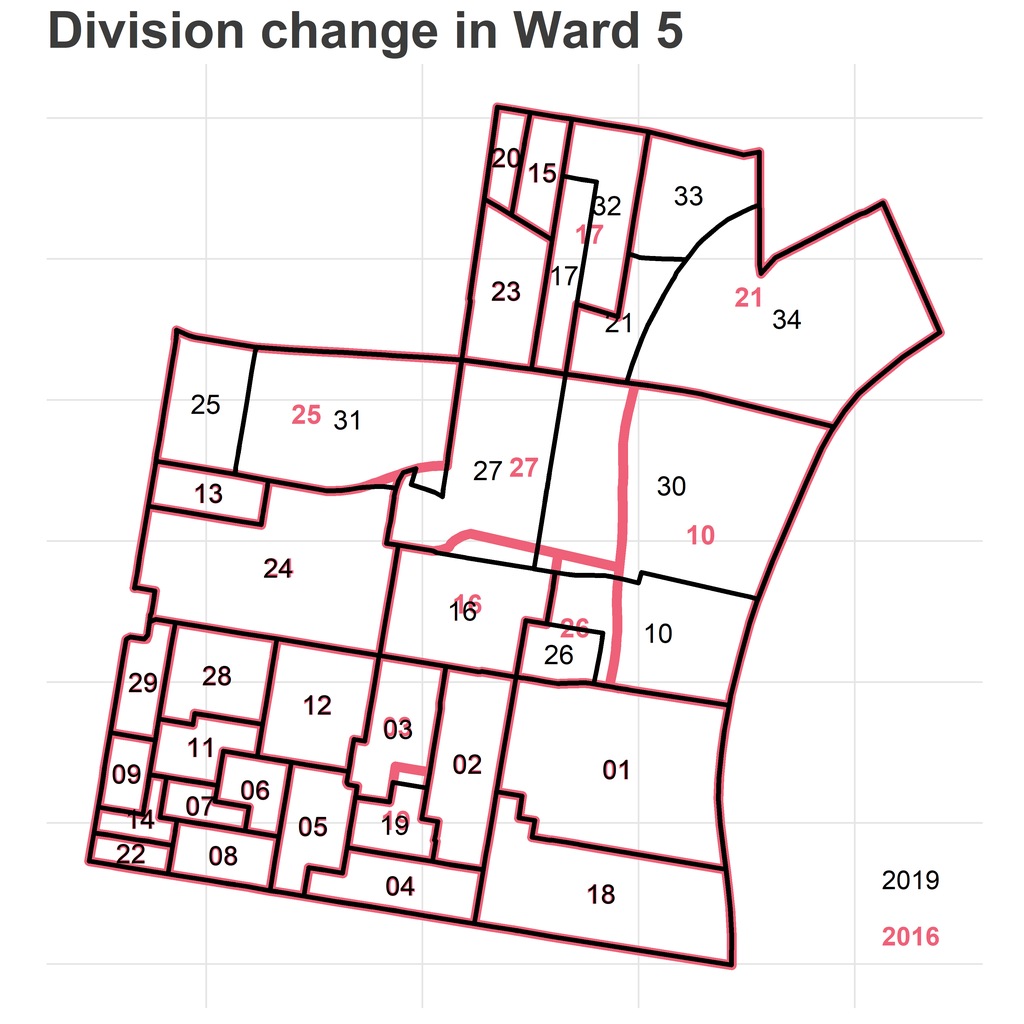

```r
library(sf)
library(dplyr)
library(tidyr)
library(ggplot2)
library(ggmap)

sixtysix_colors <- list(
  red="#D0445E",
  blue="#0077E0",
  purple="#C92EC4",
  green="#009871",
  orange="#9C7200",
  grey="#009871",
  light_red="#EE6178"
)

theme_map_sixtysix <- function(){
  ggthemes::theme_map() %+replace%
    theme(
      text = ggthemes::theme_fivethirtyeight()$text,
      title = ggthemes::theme_fivethirtyeight()$plot.title,
      panel.grid.major = element_line(color="grey90")
    )
}

divs_16 <- st_read("data/2016/2016_Ward_Divisions.shp") %>%
  rename(warddiv16 = WARD_DIVSN) %>%
  mutate(
    DIVSN = sprintf("%02d", DIVSN),
    WARD = sprintf("%02d", WARD)
  ) %>%
  st_transform(4326)
divs_19 <- st_read("data/2019/Political_Divisions.shp") %>%
  rename(warddiv19 = DIVISION_N) %>%
  mutate(WARD = substr(warddiv19, 1, 2))%>%
  st_transform(4326)
ggplot(
  divs_16 %>% filter(WARD == "05")
) +
    geom_sf(
    color = sixtysix_colors$light_red,
    size=2,
    fill=NA
  ) +
  geom_text(
    aes(x=X, y=Y, label = DIVSN),
    data = with(
      divs_16 %>% filter(WARD == "05"),
      data.frame(DIVSN, st_centroid(geometry) %>% st_coordinates())
    ),
    color=sixtysix_colors$light_red,
    size=4,
    fontface="bold"
  ) +
  geom_sf(
    data=divs_19 %>% filter(WARD == "05"),
    color = "black",
    size=1,
    fill=NA
  ) +
  geom_text(
    aes(x=X, y=Y, label = SHORT_DIV_),
    data = with(
      divs_19 %>% filter(WARD == "05"),
      data.frame(SHORT_DIV_, st_centroid(geometry) %>% st_coordinates())
    ),
    color="black",
    size=4
  ) +
  geom_text(
    aes(label=year, x=x, y=y, fontface=fontface, color=color),
    data=tribble(
      ~year, ~x, ~y, ~fontface, ~color,
      2016, -75.12607, 39.941, "bold", sixtysix_colors$light_red,
      2019, -75.12607, 39.943, "plain", "black"
    ),
    hjust=1
  ) +
  scale_color_identity(guide=FALSE) +
  theme_map_sixtysix() +
  ggtitle("Division change in Ward 5")
```

We have two types of transformations to make. Some divisions from 2016 get split up into multiple 2019 divisions: 2016’s division 21 becomes 21, 33, and 34. Also, parts of some 2016 divisions get combined to form new ones: the new division 10 consists of paste of 2016 10 and 26.

Crosswalking values is usually done pretty simply: we take the counts from the 2016 data, and apportion them to 2019 boundaries. Usually, we do this by calculating the area of the intersection (“areal weighting”):

```r
st_intersection(
  divs_16 %>% filter(warddiv16 == "0521"),
  divs_19
) %>%
  mutate(area = st_area(geometry)) %>%
  as.data.frame() %>%
  select(warddiv16, warddiv19, area) %>%
  group_by() %>%
  mutate(prop_of_16 = as.numeric(area / sum(area)))
```

```
## # A tibble: 5 x 4
##   warddiv16 warddiv19             area   prop_of_16
##      <fctr>    <fctr>      <S3: units>        <dbl>
## 1      0521      1802     66.16341 m^2 6.830745e-05
## 2      0521      0530    918.91200 m^2 9.486896e-04
## 3      0521      0534 676270.02908 m^2 6.981847e-01
## 4      0521      0533 179224.47653 m^2 1.850323e-01
## 5      0521      0521 112132.32843 m^2 1.157660e-01
```

The above shows us that Division 05-21 in 2016 was split up into five divisions for 2019. Two of them–1802 and 0530–look like noise; the areas are tiny and probably represent a trivial move in the boundary.

To apportion 2016’s votes to 2019 boundaries, we would give new division 05-34 69.8% of the votes, 05-33 18.5%, and 05-21 11.6%. Done.

> Exercise: What assumptions make this apportionment valid?